# Preguntas clave

Módulo 8, equipo 3

# 3. Preguntas guía para el proyecto.

## ¿Cómo ha evolucionado la capacidad hospitalaria en los últimos 10 años?

La base de datos para esta parte del análisis contiene 345 filas, tiene datos correspondientes a tres períodos: 2019, 2021 y 2024.

```
## tibble [345 × 4] (S3: tbl_df/tbl/data.frame)
##  $ ref_area      : chr [1:345] "MLI" "MLI" "MLI" "GTM" ...
##  $ ref_area_label: chr [1:345] "Mali" "Mali" "Mali" "Guatemala" ...
##  $ time_period   : Factor w/ 3 levels "2019","2021",..: 3 2 1 1 3 2 1 3 2 1 ...
##  $ obs_value     : num [1:345] 1 1 1 2.6 2.8 2.8 2.8 3 3 3 ...
```

La base de datos solo abarca 5 años; no se observa diferencia entre los tres períodos, acaso se nota una ligera reducción de la media.

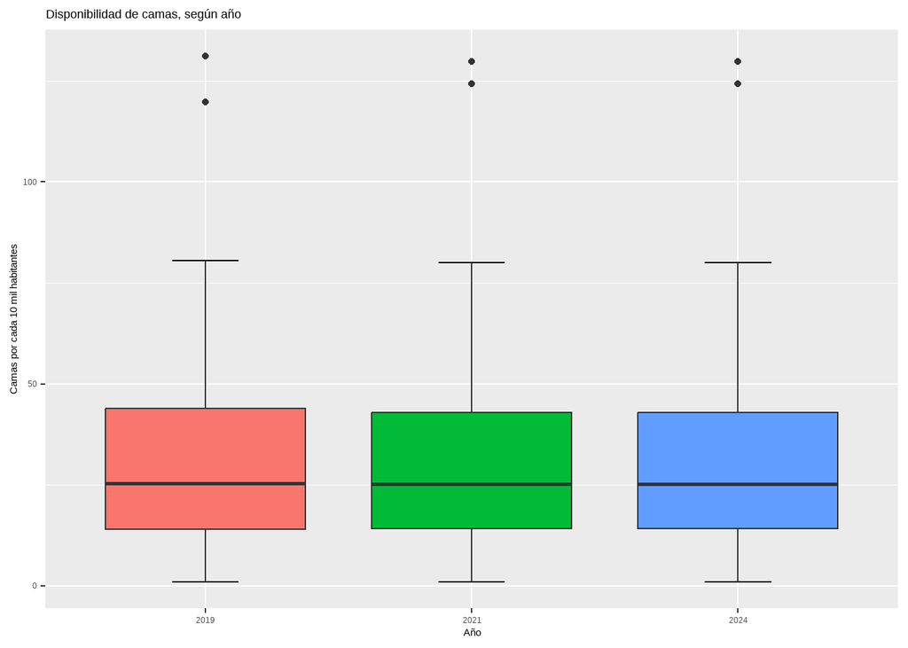

```
## # A tibble: 3 × 3
##   time_period Media DesviacionEstandar
##   <fct>       <dbl>              <dbl>
## 1 2019         31.2               23.1
## 2 2021         31.1               23.2
## 3 2024         31.1               23.2
```

# ¿Qué países (o entidades) tienen mayor y menor número de camas hospitalarias por habitante?

## Veinte países con mayor disponibilidad de camas.

Sobresalen Japón y Korea del sur, además de países del este de Europa.

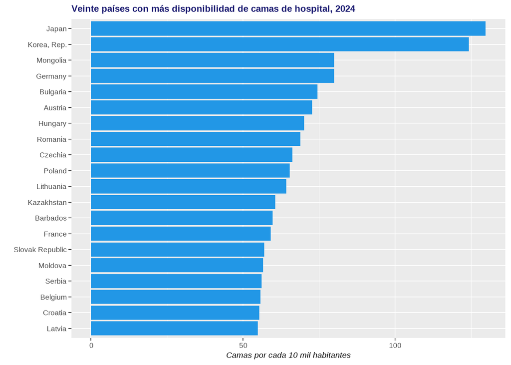

## Veinte países con menor disponibilidad de camas.

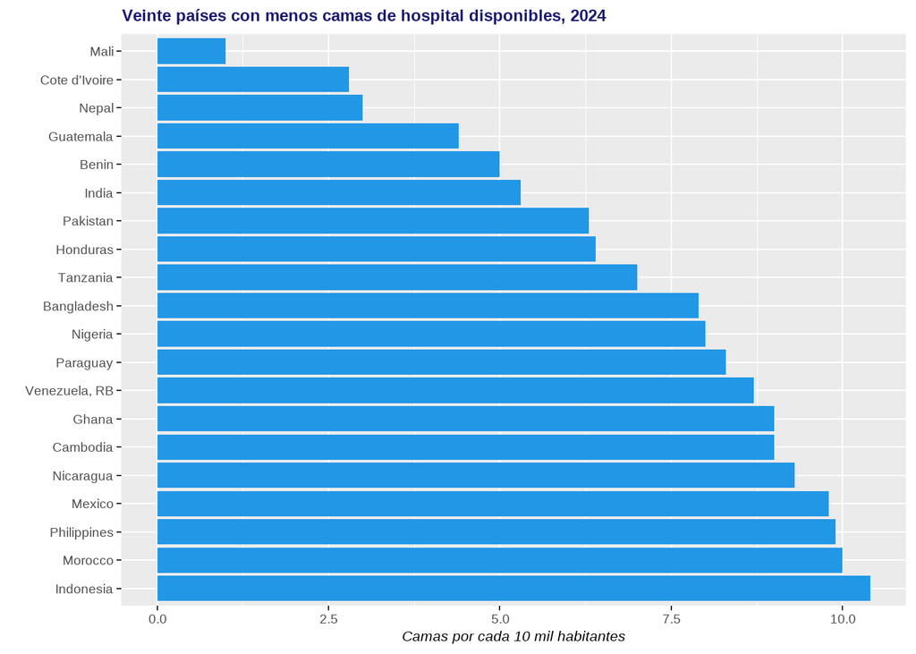

## ¿Existe relación entre el gasto en salud y la disponibilidad de camas? ¿Hay relación entre la cantidad de médicos y las tasas de mortalidad?

```
## tibble [39 × 12] (S3: tbl_df/tbl/data.frame)
##  $ id_unica       : chr [1:39] "THA2019" "IDN2019" "CHE2019" "SGP2019" ...
##  $ clave_pais     : chr [1:39] "THA" "IDN" "CHE" "SGP" ...
##  $ pais           : chr [1:39] "Thailand" "Indonesia" "Switzerland" "Singapore" ...
##  $ periodo        : num [1:39] 2019 2019 2019 2019 2019 ...
##  $ camas          : num [1:39] 21 9.9 46.9 24.8 70 2.6 39.8 28.9 44.1 10.6 ...
##  $ medicos        : num [1:39] 0.897 0.467 4.35 2.434 3.647 ...
##  $ poblacion      : num [1:39] 7.15e+07 2.72e+08 8.58e+06 5.70e+06 3.27e+06 ...
##  $ gasto_salud_por: num [1:39] 1.3 1.48 2.18 2.2 2.24 ...
##  $ mort_fem       : num [1:39] 72.5 142.3 32.2 31.7 99.1 ...
##  $ mort_mas       : num [1:39] 178.7 192.9 54.6 56.9 255 ...
##  $ pib            : num [1:39] 7813 4193 84474 66082 4309 ...
##  $ ga_salud_per   : num [1:39] 101.3 62 1839.1 1452.9 96.5 ...
```

Se consideraron dos variables para el gasto en salud: el gasto en salud como porcentaje del PIB y el gasto en salur en dólares per cápita. El segundo indicador se obtuvo multiplicando el porcentaje del PIB dedicado a salud por el PIB per cápita. La gráfica de ggpairs muestra que las correlaciones entre el gasto en salud y el número de camas son muy débiles (r=207 con % del PIB y r= 0.053 dólares per cápita) y no significativas. Por su parte, el número de médicos está correlacionado negativa y significativamente con la mortalidad femenina (r = -0.497). La correlación con la mortalidad masculina es también negativa, pero más débil (r = -0.327).

Otras correlaciones importantes son el gasto en salud percápita con las mortalidades femenina y masculina (r=-0.477 y -0.647 respectivamente). Por su parte, el número de camas no está correlacionado significativamente con una reducción de la mortalidad ni tampoco con el gasto en salud per cápita. Esto puede deberse a que el mayor gasto en salud se está haciendo en medicina preventiva y eso ayuda a reducir las tasas de mortalidad sin necesidad de que las personas ocupen camas de hospital. Un ejemplo de este razonamiento es el gasto en vacunas y en sanidad pública.

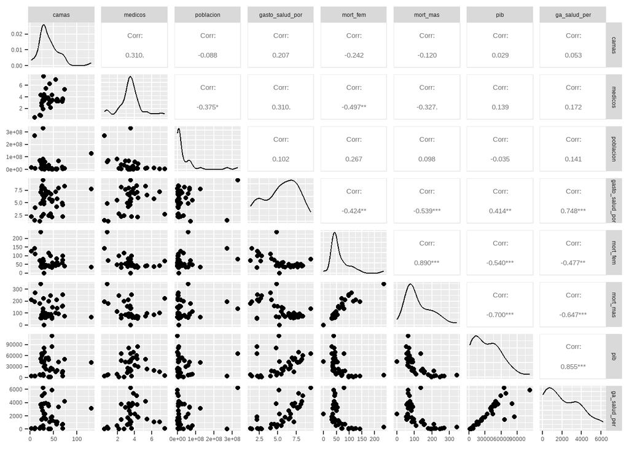

Las siguientes gráficas muestran con más detalle la relación entre las variables de interés.

Como se mencionó antes, el gasto en salud, tanto expresado como porcentaje del PIB como en dólares per cápita, muestra relaciones muy débiles con el número de camas disponibles.

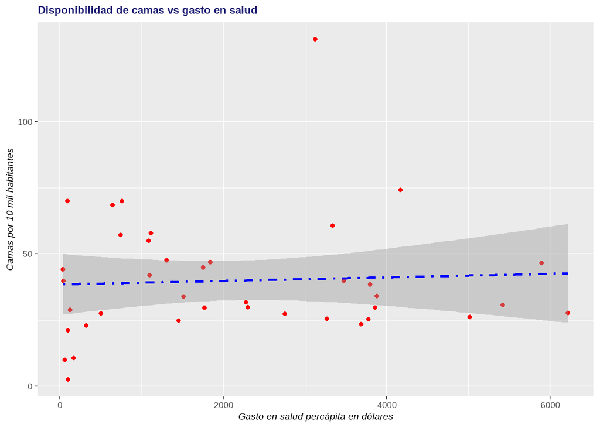

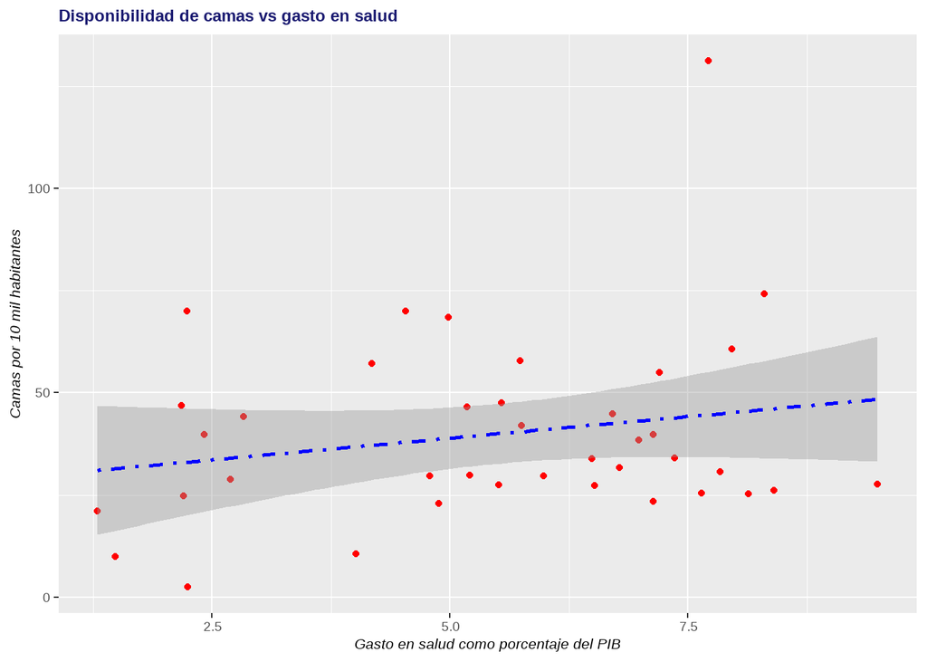

La tasa de mortalidad en la base de datos está en defunciones por cada 100 habitantes, sin embargo, los valores no son consistentes. Por ejemplo, méxico tiene una tasa de mortalidad de 6.16 defunciones por cada 1000 habitantes para 2023, pero el valor hallado en la base para 2022 es de 196 para hombres y 94 para mujeres. Para el análisis no se modificaron los datos.

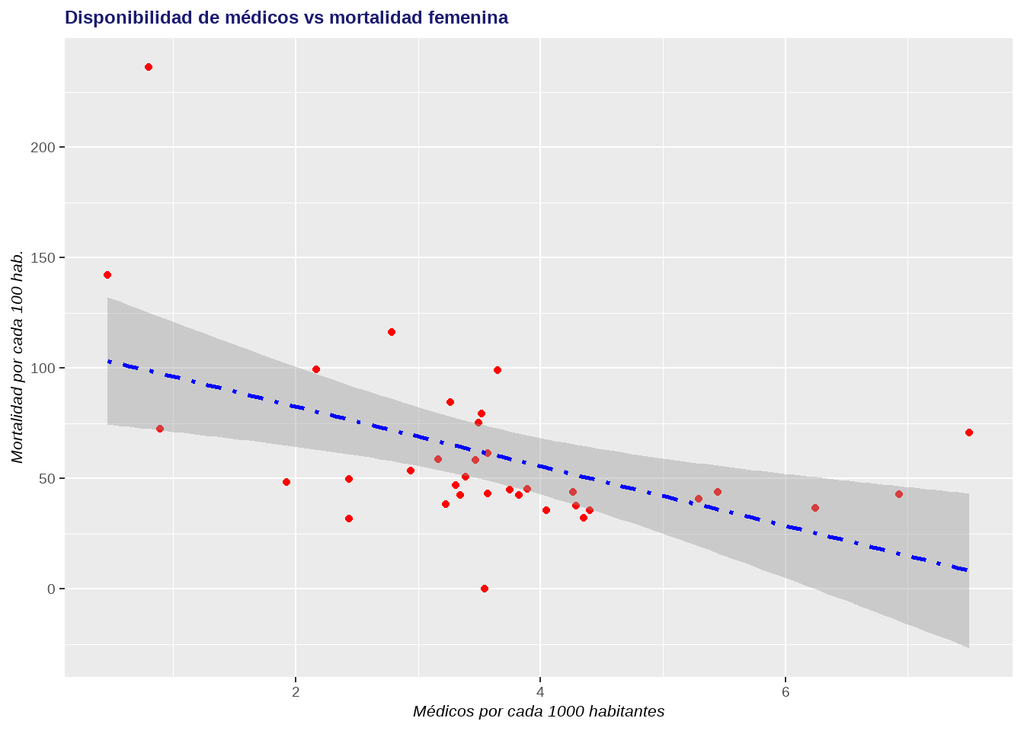

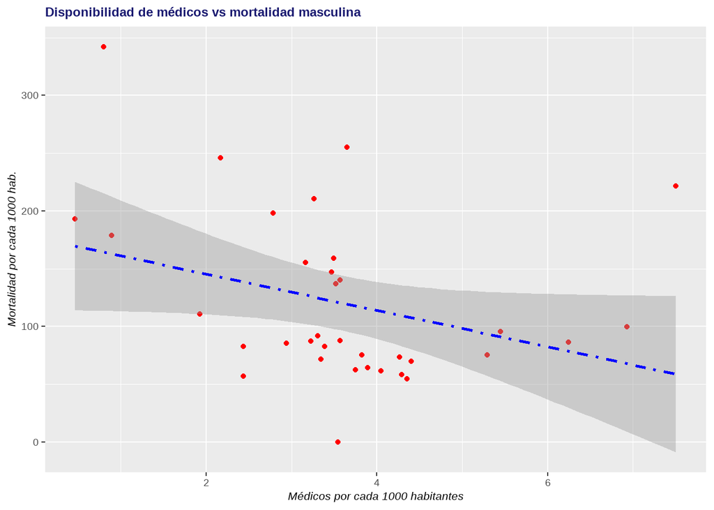

# Conclusión

El número de camas no se explica de manera importante por el gasto en salud; el número de médicos sí está correlacionado con una menor mortalidad sobre todo de las mujeres.

Las bases de datos no son muy consistentes, los valores de las distintas variables no están disponibles para todos los países y años, por lo que la base de datos con la que se trabajó fue muy limitada. Es necesario hacer una búsqueda de información más detallada para seleccionar variables con menos datos ausentes o bases de datos más completas.